# Bilan

### sous-partie2

| Dép. EP | Loc. relative | Somme Poids | Total Poids | Part Poids |
| --- | --- | --- | --- | --- |
| 971 | interieur | 1292 | 1611 | 80.2 |
| 971 | antilles-guyane | 167 | 1611 | 10.4 |
| 971 | autres | 152 | 1611 | 9.4 |
| 972 | interieur | 1866 | 2478 | 75.3 |
| 972 | antilles-guyane | 401 | 2478 | 16.2 |
| 972 | autres | 211 | 2478 | 8.5 |
| 973 | interieur | 477 | 519 | 91.9 |
| 973 | antilles-guyane | 26 | 519 | 5.0 |
| 973 | autres | 16 | 519 | 3.1 |

Alors, dans ces données, on voit que les grandes entreprises des Antilles et de la Guyane ont souvent leurs filiales à l’intérieur de leur propre département. Par exemple, dans le 971, 80% des filiales sont là-bas même, et dans le 972, c’est 75%. C’est clair que c’est plus facile pour eux de contrôler les choses quand tout est proche. Mais parfois, ça peut être juste une coïncidence ou un hasard, pas forcément parce qu’ils veulent vraiment tout avoir sous la main. Et puis, il y a aussi des filiales dans d’autres départements, mais c’est beaucoup moins fréquent.

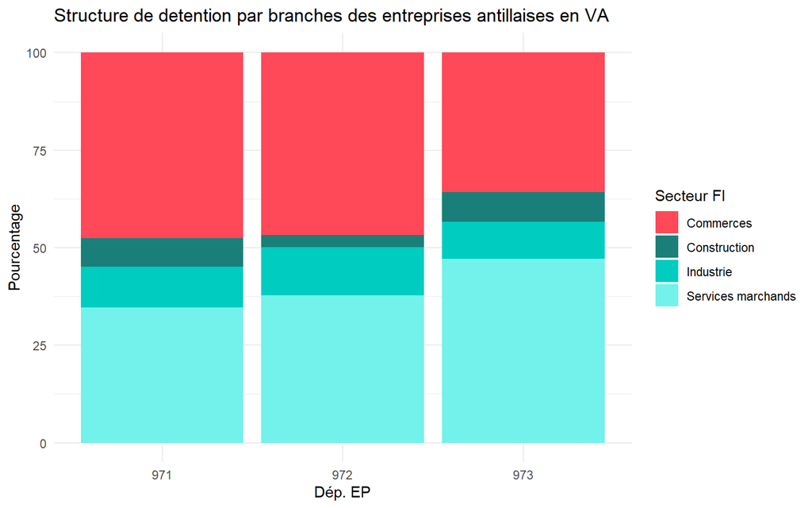

C’est clair, on va jeter un coup d’œil sur ces données et voir ce qui se passe.

Alors, en Guadeloupe (971), les grandes entreprises (entreprise_profilée) dans le commerce font beaucoup de fric (chiffre_affaires). On parle de 543 thunes gagnées sur un total de 1139. Les services marchands sont aussi bien placés avec 394 thunes. La construction et l’industrie, elles, ramènent beaucoup moins de pépètes (83 et 119 thunes respectivement).

En Martinique (972), c’est pareil : le commerce et les services marchands dominent avec 967 et 783 thunes. La construction et l’industrie, elles, font moins de bruit (64 et 254 thunes).

En Guyane (973), c’est un peu différent. Les entreprises dans les services marchands roulent sur l’or avec 103 thunes sur un total de 219. Le commerce arrive juste après avec 78 thunes. La construction et l’industrie, elles, sont loin derrière (17 et 21 thunes).

Voilà ce qu’on peut dire des grandes entreprises aux Antilles et en Guyane.

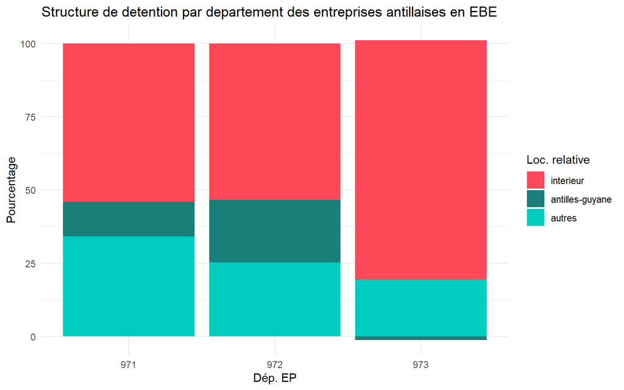

Alors, pour ce qui est des grandes entreprises aux Antilles-Guyane, on voit que celles de Guadeloupe (971) et Martinique (972) dominent le terrain. Elles ont plein de filiales qui leur rapportent du fric, surtout celles qui sont dans la même région. Par exemple, en Guadeloupe, 54% des thunes gagnées par les filiales viennent de celles qui sont là-bas. En Martinique, c’est pareil, avec 53%. Pour Guyane (973), c’est un peu différent, mais on peut dire que c’est parce qu’elles ont moins de filiales et donc moins de thunes à se partager. C’est clair qu’elles pourraient faire mieux si elles avaient plus de soutien.